# ch12 Factors

JustY

## 12.1 forcats로하는팩터형 들어가기

R에서 팩터형은 범주형 변수에 사용되는데, 범주형변수란 가질수 있는 값이 미리고정되고 또알려진 변수를 말한다.팩터형은 문자형 벡터를 알파벳순이 아닌 순서로 표시하고 싶을 떄도이용할수있다. 팩터형의 역사적 맥락을 자세히 보려면 로커 팽의 (stringASfactor:an unauthorized biography) 와 토마스럼리 의 (stringasfacter=sigh)를 읽오보길 바랍니다

### 12.1.1 forcats로하는 팩터형 준비하기

팩터형을 다루기위해 forcats 패키지를 사용하려는데,이패키지에는 범주형ㅇ 뱐수(팩터형의 다른말) 에적요하는 도구들이있다 forcats는 tidyverse 핵심 구성원에 포함되어있지 않기 떄문에 명시적으로 로드해야 한다.

```r
library(tidyverse)
library(forcats)
```

## 12.2 팩터형 생성하기

월을 기록한 변수가 있다고 가정하자

```r
x1 <- c("Dec","Apr","Jan","Mar")
```

1.12개의 달 외의 오타를 입력했을떄,경고가 발생되지않아 실수를 알아채기 어렵다

```r
x2 <- c("Dec","Apr","Jam","Mar")
```

2.유용한 순서로 정렬되지 않는다

```r
sort(x1)
```

```
## [1] "Apr" "Dec" "Jan" "Mar"
```

팩터형을 이용하면 이러한 문제를 모두 해결할수있다.팩터형을 생성하기위해서는 유요한 레벨들의 리스트를 생성하는 것부터 시작해야 한다

```r
month_levels <- c("Jan","Fed","Mar","Apr","May","Jun","Jul","Aug","Sep","Oct","Nov","Dec")
```

이제 팩터형을 사용할수있다 그리고 이레벨 집합에 포함되지 않는값은 조용히 NA로 변환된다

```r
y2 <- factor(x2, levels = month_levels)
y2
```

```
## [1] Dec  Apr  <NA> Mar
## Levels: Jan Fed Mar Apr May Jun Jul Aug Sep Oct Nov Dec
```

경고가발생되길 원하는 경우에는 readr::parse_factor()를 사용하면 된다.

```r
y2 <- parse_factor(x2, levels = month_levels)
```

```
## Warning: 1 parsing failure.
## row col           expected actual
##   3  -- value in level set    Jam
```

## 12.3 종합사회조사

시카고 대학 독립연구기관인 NORC 에서 장기간 수행한 미국내 설문조사(General Social Survey)의 샘플 데이터이다.수천개의 문항이있는데, 이중에서도 팩터형과 작업할떄 자주발생하는 문제를 보여주는 것들을 gss_cat 으로 선택했다.

```r
gss_cat
```

```
## # A tibble: 21,483 x 9
##     year marital     age race  rincome    partyid     relig     denom    tvhours
##    <int> <fct>     <int> <fct> <fct>      <fct>       <fct>     <fct>      <int>
##  1  2000 Never ma~    26 White $8000 to ~ Ind,near r~ Protesta~ Souther~      12
##  2  2000 Divorced     48 White $8000 to ~ Not str re~ Protesta~ Baptist~      NA
##  3  2000 Widowed      67 White Not appli~ Independent Protesta~ No deno~       2
##  4  2000 Never ma~    39 White Not appli~ Ind,near r~ Orthodox~ Not app~       4
##  5  2000 Divorced     25 White Not appli~ Not str de~ None      Not app~       1
##  6  2000 Married      25 White $20000 - ~ Strong dem~ Protesta~ Souther~      NA
##  7  2000 Never ma~    36 White $25000 or~ Not str re~ Christian Not app~       3
##  8  2000 Divorced     44 White $7000 to ~ Ind,near d~ Protesta~ Luthera~      NA
##  9  2000 Married      44 White $25000 or~ Not str de~ Protesta~ Other          0
## 10  2000 Married      47 White $25000 or~ Strong rep~ Protesta~ Souther~       3
## # ... with 21,473 more rows
```

팩터형이 티블로 저장되면 해당하는 레벨들을 쉽게 볼수없게 된다.볼수있는 한가지 방법은 count()이다

```r
gss_cat %>%
  count(race)
```

```
## # A tibble: 3 x 2
##   race      n
##   <fct> <int>
## 1 Other  1959
## 2 Black  3129
## 3 White 16395
```

또는 그래프로도 볼수있다

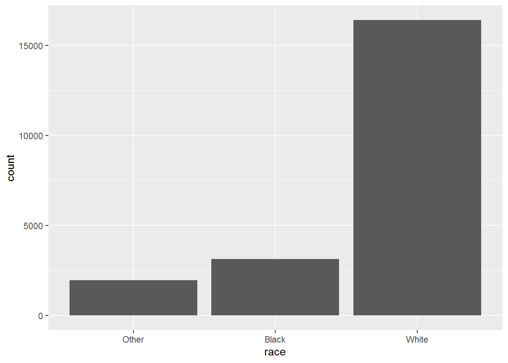

```r
ggplot(gss_cat, aes(race)) +
  geom_bar()
```

기본적으로 ggplot2는 값이없는 레벨을 제거한다.다음과같이 강제적으로 표시하도록 할수있다

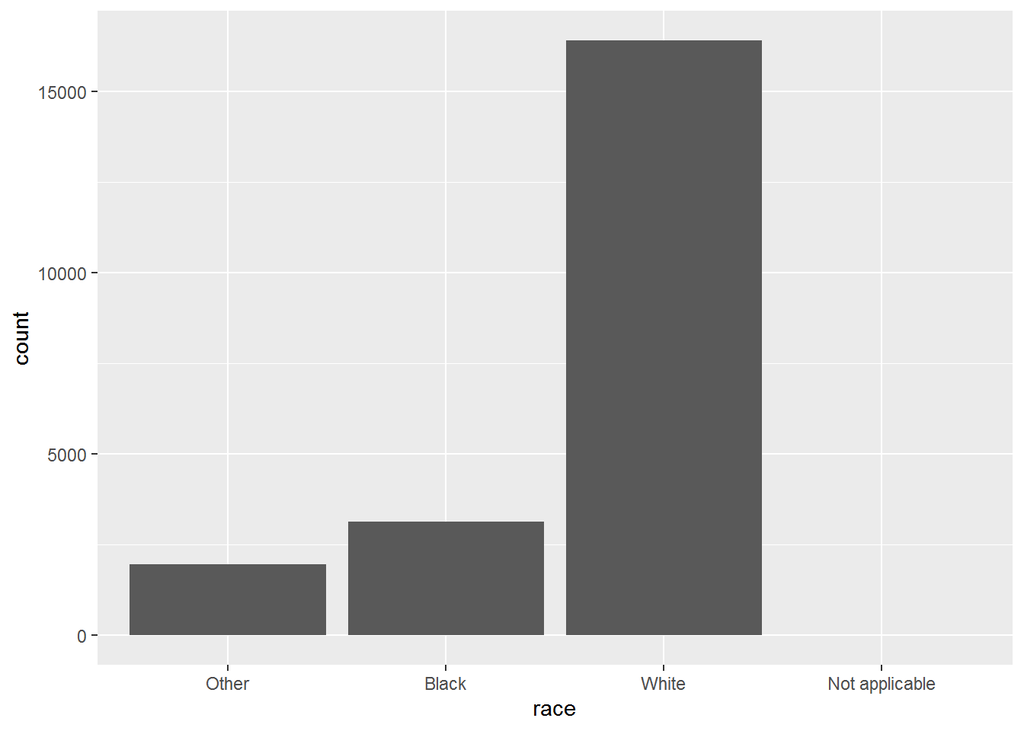

```r
ggplot(gss_cat, aes(race)) +
  geom_bar() +
  scale_x_discrete(drop = FALSE)
```

이레벨들은 유효하지만 이 데이터셋에서 나타나지 않는 값을 나타낸다.dplyr 에는 drop 옵션이 아직 없짐나 행후 제공될 예정이다.펙터형으로 작업할떄 자주하는 작업 두가지는 레벨의 순서와 값을 변경하는 것이다.

## 12.4 팩터 순서 수정하기

시각화에서 팩터 레벨의 순서를 변경하는 것이 유용할 떄가 종종 있다.예를들어 종교에 따른 하루 tv시청시간의 평균을 탐색하고 싶다고 해보자.

```r
relig_summary <- gss_cat %>%
  group_by(relig) %>%
  summarize(
    age = mean(age, na.rm = TRUE),
    tvhours = mean(tvhours, na.rm = TRUE),
  )
```

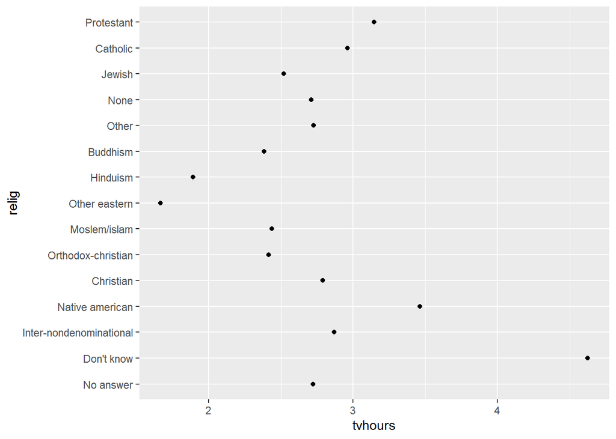

```r
ggplot(relig_summary, aes(tvhours, relig)) + geom_point()
```

*f:레벨을 수정할 팩터

*x:레벨을 재정렬하기 위해 사용할 수치형 벡터

*선택적으로 fun:f의 각 값에 대해 x값이 여러개가 있을떄 사용할 함수. 기본값은 median 이다

```r
rincome_summary <- gss_cat %>%
  group_by(rincome) %>%
  summarize(
    age = mean(age, na.rm = TRUE),
    tvhours = mean(tvhours, na.rm = TRUE),
  )
```

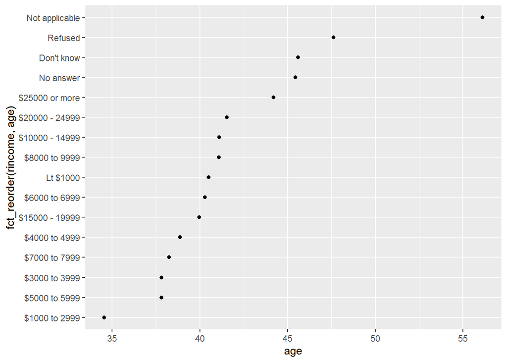

```r
ggplot(rincome_summary, aes(age, fct_reorder(rincome, age))) + geom_point()
```

여기에서 레벨을 임의로 재정렬하는 것은 좋은 생각이 아니다 rincome은 이미 원칙있게 정렬되어 있어서 건드리지 말아야 하기떄문이다. fct_reorder() 는레벨이 임의적으로 정렬된 팩터의 경우에만 사용해야한다 해당없음(Not applicable) 을 다른 특별한 레벨들과 함께 앞으로 가져오는 것이 좋다 fct_relevel()을사용하면된다 팩터형 f와 앞으로 옮기고자 하는레벨 을 입력하면된다.

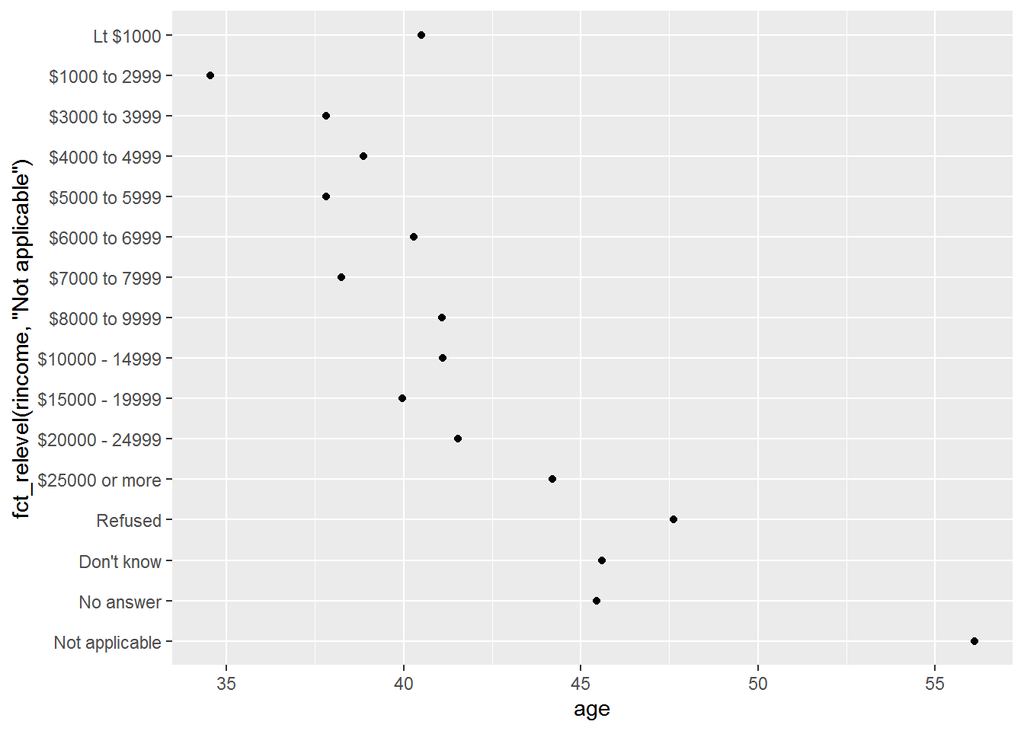

```r
ggplot(rincome_summary, aes(age, fct_relevel(rincome, "Not applicable"))) +
  geom_point()
```

재정렬이 유용한 경우가 있는데,플롯의 선에 색상을 입힐떄이다.fct_reorder2()는 가장 큰x값과 연관된 y값으로 팩터형을 재정렬한다.선 색상 은 범례와 정렬 되므로 이렇게하면 플롯 읽기가 쉬워진다

[figure not shown]

```r
by_age <- gss_cat %>%
  filter(!is.na(age)) %>%
  group_by(age, marital) %>%
  count() %>%
  mutate(prop = n / sum(n))

ggplot(by_age, aes(age, prop, color = marital)) +
  geom_line(na.rm = TRUE)
```

[figure not shown]

```r
ggplot(by_age, aes(age, prop, color = fct_reorder2(marital, age, prop))) +
  geom_line() +
  labs(color = "marital")
```

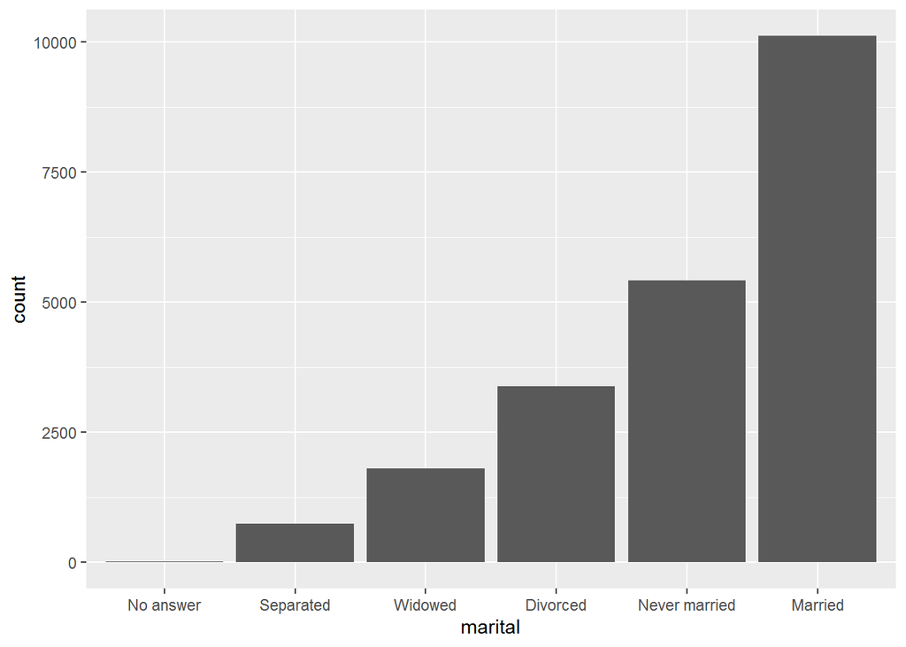

```r
gss_cat %>%
  mutate(marital = marital %>% fct_infreq() %>% fct_rev()) %>% ggplot(aes(marital)) +
  geom_bar()
```

## 12.5 팩터 레벨 수정하기

레벨의 순서 변경보다 값을 변경하는게 강력한 방법이다. 화면출력시 라벨을 명확히 할수 있고, 레벨을 병합하여 상위 레벨 시각화를 할수있다. fct_recode 가 일반적이며 각레벨값을 변경할수있다. 예를들어 gss_cat$partyid 를보자

```r
gss_cat %>% count(partyid)
```

```
## # A tibble: 10 x 2
##    partyid                n
##    <fct>              <int>
##  1 No answer            154
##  2 Don't know             1
##  3 Other party          393
##  4 Strong republican   2314
##  5 Not str republican  3032
##  6 Ind,near rep        1791
##  7 Independent         4119
##  8 Ind,near dem        2499
##  9 Not str democrat    3690
## 10 Strong democrat     3490
```

이레벨들을 풀어쓰고 병렬구조를 사용해보자

```r
gss_cat %>%
  mutate(partyid = fct_recode(partyid,
    "Republican, strong" = "strong republican",
    "Republican, weak" = "Not str republican",
    "Independent, near rep" = "Ind,near rep",
    "Independent, near dem" = "Ind,near dem",
    "Democrat, weak" = "Not str democrat",
    "Democrat, strong" = "strong democrat"
  )) %>%
  count(partyid)
```

```
## Warning: Problem with `mutate()` input `partyid`.
## i Unknown levels in `f`: strong republican, strong democrat
## i Input `partyid` is `fct_recode(...)`.
```

```
## Warning: Unknown levels in `f`: strong republican, strong democrat
```

```
## # A tibble: 10 x 2
##    partyid                   n
##    <fct>                 <int>
##  1 No answer               154
##  2 Don't know                1
##  3 Other party             393
##  4 Strong republican      2314
##  5 Republican, weak       3032
##  6 Independent, near rep  1791
##  7 Independent            4119
##  8 Independent, near dem  2499
##  9 Democrat, weak         3690
## 10 Strong democrat        3490
```

```r
gss_cat %>%
  mutate(partyid = fct_recode(partyid,
    "Republican, strong" = "strong republican",
    "Republican, weak" = "Not str republican",
    "Independent, near rep" = "Ind,near rep",
    "Independent, near dem" = "Ind,near dem",
    "Democrat, weak" = "Not str democrat",
    "Democrat, strong" = "strong democrat"
    )) %>%
    count(partyid)
```

```
## Warning: Problem with `mutate()` input `partyid`.
## i Unknown levels in `f`: strong republican, strong democrat
## i Input `partyid` is `fct_recode(...)`.
```

```
## Warning: Unknown levels in `f`: strong republican, strong democrat
```

```
## # A tibble: 10 x 2
##    partyid                   n
##    <fct>                 <int>
##  1 No answer               154
##  2 Don't know                1
##  3 Other party             393
##  4 Strong republican      2314
##  5 Republican, weak       3032
##  6 Independent, near rep  1791
##  7 Independent            4119
##  8 Independent, near dem  2499
##  9 Democrat, weak         3690
## 10 Strong democrat        3490
```

[output not shown]

가끔은 플룻이나 테이블을 간단히 만들기위해 소규모 그룹 모두를 묶고 싶을수도있다 fct_lump()가 바로그떄쓰는작업이다

```r
gss_cat %>%
  mutate(relig = fct_lump(relig)) %>%
  count(relig)
```

```
## # A tibble: 2 x 2
##   relig          n
##   <fct>      <int>
## 1 Protestant 10846
## 2 Other      10637
```

기본동작은 묶은 그룹이 가장 작은 그룹이 되는 조건을 유지하면서 작은 그룹 들을 점진적으로 묶는다 N 인수를 사용하여 유지하고 싶은 그룹 개수(other 제외)를 지정할수있다

```r
gss_cat %>%
  mutate(relig = fct_lump(relig, n = 10)) %>%
  count(relig, sort = TRUE) %>%
  print(n = Inf)
```

```
## # A tibble: 10 x 2
##    relig                       n
##    <fct>                   <int>
##  1 Protestant              10846
##  2 Catholic                 5124
##  3 None                     3523
##  4 Christian                 689
##  5 Other                     458
##  6 Jewish                    388
##  7 Buddhism                  147
##  8 Inter-nondenominational   109
##  9 Moslem/islam              104
## 10 Orthodox-christian         95
```